# Predicting Equity Returns from Company Fundamentals and Macro Conditions

Kyle Ruby and Nora Humfeld

**Introduction**

Can company fundamentals and macroeconomic conditions predict next-month equity returns? This is a long-standing debate in finance, with textbooks, academic papers, and working investors all landing in different places. We wanted to throw a reasonable set of features at the problem and see what a model could find on its own.

We pulled monthly data on 40 large-cap U.S. stocks across 8 sectors from 2005 to 2024. Firm-level fundamentals come from LSEG, macro indicators from FRED, and stock prices from Yahoo Finance. Our model is a Random Forest predicting the forward one-month return, defined as the next-month percent change in adjusted closing price. This is not Return on Equity (ROE), which appears in our feature set as a predictor.

The main finding is that the model has something that we'll call conditional skill. On the full test set, performance is barely positive (R² of about 0.0062). But when we split the test period into macro regimes, the model has predictive power in stagflation-like environments and is actively unhelpful in low-rate, low-inflation ones.

**Datasets**

> LSEG (Worldscope) provides annual firm-level fundamentals for our 40 tickers (profitability, leverage, liquidity, growth).

> FRED provides monthly macro series (Fed Funds Rate, CPI, 10y/3m yield spread, unemployment).

> Yahoo Finance provides monthly OHLCV prices, used to construct the forward-return target.

The 40 tickers were chosen to give five large-cap names from eight industry sectors. The sample is survivor-biased toward names that traded continuously across the full window.

**Project Goals**

Four steps. Load and merge three differently-shaped datasets into one panel, build the forward-return target, train a Random Forest and compare it to baselines, and slice the test set across macro regimes to see where the model actually works.

# Data Curation, Parsing, and Management

We start by importing the libraries we'll use throughout and mounting Google Drive, where the raw files live.

```python
import pandas as pd
import numpy as np
import matplotlib.pyplot as plt
import seaborn as sns

# Data paths
BASE = '/content/drive/MyDrive/Data Science Project/Data'
FRED_DIR = f'{BASE}/FRED'
LSEG_DIR = f'{BASE}/LSEG (COMP FUNDAMENTALS)'
YAHOO_DIR = f'{BASE}/Yahoo'

from google.colab import drive
drive.mount('/content/drive')
```

## Datasets

### Dataset 1: FRED

The first data set is from the St. Louis Federal Reserve Bank, containing four monthly attributes:

> **Federal Funds Rate**: the rate banks lend reserve balances to each other overnight, set by the FOMC.

> **Consumer Price Index (CPI)**: the average price change of a representative basket of consumer goods. Standard inflation gauge.

> **10-year minus 2-year treasury yield spread**: the difference between long and short term bond yields. Historically predicts recessions when negative.

> **Unemployment rate**: the percentage of the labor force without a job.

This dataset doesn't contain our target variable, but it captures abstract factors like consumer confidence and the cost of capital that show up in equity valuations. Pulled via API, one observation is populated for the first of each month from 2005 to 2025.

Source: https://fred.stlouisfed.org/

#### Pre-processing

```python
fred = pd.read_csv(f'{FRED_DIR}/fred.csv')
fred.head()
```

|  | Date | Fed_Funds_Rate | CPI | Yield_Spread | Unemployment |
| --- | --- | --- | --- | --- | --- |
| 0 | 1/1/2005 | 2.28 | 191.6 | 1.00 | 5.3 |
| 1 | 2/1/2005 | 2.50 | 192.4 | 0.79 | 5.4 |
| 2 | 3/1/2005 | 2.63 | 193.1 | 0.77 | 5.2 |
| 3 | 4/1/2005 | 2.79 | 193.7 | 0.69 | 5.2 |
| 4 | 5/1/2005 | 3.00 | 193.6 | 0.50 | 5.1 |

```python
fred.info()
```

```
<class 'pandas.core.frame.DataFrame'>
RangeIndex: 241 entries, 0 to 240
Data columns (total 5 columns):
 #   Column          Non-Null Count  Dtype
---  ------          --------------  -----
 0   Date            241 non-null    object
 1   Fed_Funds_Rate  241 non-null    float64
 2   CPI             241 non-null    float64
 3   Yield_Spread    241 non-null    float64
 4   Unemployment    241 non-null    float64
dtypes: float64(4), object(1)
memory usage: 9.5+ KB
```

The last four datatypes are appropriately labeled as numerical floats, but the date is mischaracterized as an object. Lets use pandas internal function to fix that.

```python
# Convert the 'Date' column to datetime objects
fred['Date'] = pd.to_datetime(fred['Date'])
fred.info()
```

```
<class 'pandas.core.frame.DataFrame'>
RangeIndex: 241 entries, 0 to 240
Data columns (total 5 columns):
 #   Column          Non-Null Count  Dtype
---  ------          --------------  -----
 0   Date            241 non-null    datetime64[ns]
 1   Fed_Funds_Rate  241 non-null    float64
 2   CPI             241 non-null    float64
 3   Yield_Spread    241 non-null    float64
 4   Unemployment    241 non-null    float64
dtypes: datetime64[ns](1), float64(4)
memory usage: 9.5 KB
```

Now let's visualize the four series together. They live on very different scales (Fed Funds in percent, CPI as an index near 250+), so we apply a MinMaxScaler to make the trends comparable on one axis.

```python
from sklearn.preprocessing import MinMaxScaler
scaler = MinMaxScaler()

fred_scaled = fred.copy()
fred_scaled[['Fed_Funds_Rate', 'CPI', 'Yield_Spread', 'Unemployment']] = scaler.fit_transform(fred[['Fed_Funds_Rate', 'CPI', 'Yield_Spread', 'Unemployment']])
fred_scaled.head()
```

|  | Date | Fed_Funds_Rate | CPI | Yield_Spread | Unemployment |
| --- | --- | --- | --- | --- | --- |
| 0 | 2005-01-01 | 0.422348 | 0.000000 | 0.513298 | 0.166667 |
| 1 | 2005-02-01 | 0.464015 | 0.006281 | 0.457447 | 0.175439 |
| 2 | 2005-03-01 | 0.488636 | 0.011778 | 0.452128 | 0.157895 |
| 3 | 2005-04-01 | 0.518939 | 0.016489 | 0.430851 | 0.157895 |
| 4 | 2005-05-01 | 0.558712 | 0.015703 | 0.380319 | 0.149123 |

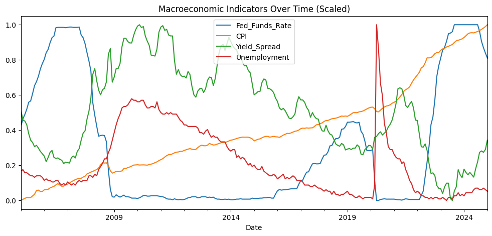

```python
fred_scaled.plot(x='Date', figsize=(12,5), title='Macroeconomic Indicators Over Time (Scaled)')
plt.show()
```

The 2008 financial crisis and the COVID-era inflation spike are both visible. This is a useful sanity check that the data matches what we'd expect from this time period. . Correctly integrating the date column into our other data sets will be important for contexualization.

CPI and the Federal Funds Rate are worth looking at side by side because their relationship shows up later in the regime analysis. When inflation rises, the Fed typically raises rates in response. The plot below shows this with a 10x scalar applied to the Fed Funds Rate so the smaller magnitude doesn't get lost next to CPI at x2.

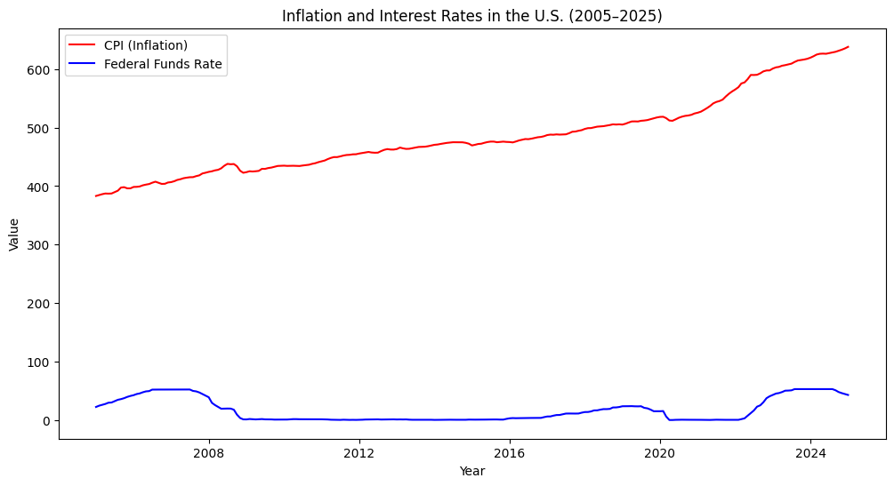

```python
plt.figure(figsize=(12,6))

plt.plot(fred['Date'], fred['CPI']*2, label='CPI (Inflation)', color='red')
plt.plot(fred['Date'], fred['Fed_Funds_Rate']*10, label='Federal Funds Rate', color='blue')
plt.xlabel("Year")
plt.ylabel("Value")
plt.title("Inflation and Interest Rates in the U.S. (2005–2025)")
plt.legend()

plt.show()
```

### Dataset 2: LSEG

#### Pre-processing

```python
import glob

# Get all csv files from the LSEG folder specifically
csv_files = glob.glob(f'{LSEG_DIR}/*.csv')

lseg_list = []
for file in csv_files:
    df = pd.read_csv(file)
    lseg_list.append(df)

lseg = pd.concat(lseg_list, ignore_index=True)
print(f"Loaded {len(csv_files)} LSEG files, {len(lseg)} total rows")
display(lseg.head())
```

```
Loaded 8 LSEG files, 836 total rows
```

|  | Ticker | year_ | InfoCode | MarketDate | typ | code | coderank | inforank | freq | ITEM5350 | ... | ITEM8301 | ITEM8306 | ITEM8311 | ITEM8316 | ITEM8326 | ITEM8366 | ITEM8376 | ITEM8601 | ITEM8631 | ITEM8636 |
| --- | --- | --- | --- | --- | --- | --- | --- | --- | --- | --- | --- | --- | --- | --- | --- | --- | --- | --- | --- | --- | --- |
| 0 | COP | 2004.0 | 63203 | 11/29/2005 | 1.0 | 46422.0 | 1.0 | 1.0 | A | 2004-12-31 | ... | 21.08991 | 14.03651 | 10.57960 | 11.29221 | 9.68421 | 6.84726 | 15.17448 | 72.68657 | 31.19426 | 71.67899 |
| 1 | COP | 2005.0 | 63203 | 11/07/2006 | 1.0 | 46422.0 | 1.0 | 1.0 | A | 2005-12-31 | ... | 28.34664 | 14.78033 | 10.70287 | 12.58459 | 13.86987 | 8.33041 | 22.11269 | 66.46500 | 36.79782 | 66.42884 |
| 2 | COP | 2006.0 | 63203 | 01/04/2007 | 1.0 | 46422.0 | 1.0 | 1.0 | A | 2006-12-31 | ... | 22.97288 | 17.99043 | 13.81446 | 15.25439 | 11.96861 | 9.27926 | 18.32364 | 0.31153 | 3.18525 | 14.93828 |
| 3 | COP | 2007.0 | 63203 | 01/08/2008 | 1.0 | 46422.0 | 1.0 | 1.0 | A | 2007-12-31 | ... | 13.85663 | 16.37493 | 13.29446 | 13.25015 | 7.42032 | 6.93353 | 11.40397 | -25.25880 | 2.34040 | -23.53055 |
| 4 | COP | 2008.0 | 63203 | 01/05/2009 | 1.0 | 46422.0 | 1.0 | 1.0 | A | 2008-12-31 | ... | -23.58409 | 15.34619 | 10.50332 | 12.04220 | -10.22671 | -7.54046 | -16.76212 | NaN | 31.44257 | NaN |

5 rows × 25 columns

The default LSEG column names look like 'ITEM5350' and aren't useful. We rename everything to readable labels using the LSEG data dictionary.

```python
# Rename columns for financial info contextualization
lseg.columns = ['Ticker', 'year_', 'InfoCode', 'MarketDate', 'typ', 'code', 'coderank',
       'inforank', 'freq', 'FiscalCloseDate', 'QuickRatio', 'CurrentRatio', 'LongTermDebtToCapital',
       'TotalDebtToEquity', 'EBITToInterestExpense', 'ReturnOnEquityToTotal', 'GrossProfitMargin', 'CashFlowToSales', 'OperatingProfitMargin',
       'ReturnOnAssets', 'NetMargin', 'ReturnOnInvestedCapital', 'EarningPerShare1Yr', 'NetSaleToRev1Yr', 'NetIncome1Yr']

lseg.head()
```

|  | Ticker | year_ | InfoCode | MarketDate | typ | code | coderank | inforank | freq | FiscalCloseDate | ... | ReturnOnEquityToTotal | GrossProfitMargin | CashFlowToSales | OperatingProfitMargin | ReturnOnAssets | NetMargin | ReturnOnInvestedCapital | EarningPerShare1Yr | NetSaleToRev1Yr | NetIncome1Yr |
| --- | --- | --- | --- | --- | --- | --- | --- | --- | --- | --- | --- | --- | --- | --- | --- | --- | --- | --- | --- | --- | --- |
| 0 | COP | 2004.0 | 63203 | 11/29/2005 | 1.0 | 46422.0 | 1.0 | 1.0 | A | 2004-12-31 | ... | 21.08991 | 14.03651 | 10.57960 | 11.29221 | 9.68421 | 6.84726 | 15.17448 | 72.68657 | 31.19426 | 71.67899 |
| 1 | COP | 2005.0 | 63203 | 11/07/2006 | 1.0 | 46422.0 | 1.0 | 1.0 | A | 2005-12-31 | ... | 28.34664 | 14.78033 | 10.70287 | 12.58459 | 13.86987 | 8.33041 | 22.11269 | 66.46500 | 36.79782 | 66.42884 |
| 2 | COP | 2006.0 | 63203 | 01/04/2007 | 1.0 | 46422.0 | 1.0 | 1.0 | A | 2006-12-31 | ... | 22.97288 | 17.99043 | 13.81446 | 15.25439 | 11.96861 | 9.27926 | 18.32364 | 0.31153 | 3.18525 | 14.93828 |
| 3 | COP | 2007.0 | 63203 | 01/08/2008 | 1.0 | 46422.0 | 1.0 | 1.0 | A | 2007-12-31 | ... | 13.85663 | 16.37493 | 13.29446 | 13.25015 | 7.42032 | 6.93353 | 11.40397 | -25.25880 | 2.34040 | -23.53055 |
| 4 | COP | 2008.0 | 63203 | 01/05/2009 | 1.0 | 46422.0 | 1.0 | 1.0 | A | 2008-12-31 | ... | -23.58409 | 15.34619 | 10.50332 | 12.04220 | -10.22671 | -7.54046 | -16.76212 | NaN | 31.44257 | NaN |

5 rows × 25 columns

LSEG has a lot of overlapping fundamental ratios. Profitability alone has six versions with ROE, ROA, ROIC, gross margin, operating margin, and net margin. These are very correlated, and giving all of them to a tree-based model would split the importance across similar features. We are keeping one ratio per dimension and have decided ROE for profitability, debt-to-equity for leverage, current ratio for liquidity, and EPS growth for growth. We end up with four features instead of fourteen, and the model still has access to the underlying signal.

```python
lseg = lseg.drop(columns=['MarketDate', 'FiscalCloseDate', 'InfoCode', 'typ',
                          'code', 'coderank', 'inforank', 'freq',
                          # Profitability:keep only ROE
                          'ReturnOnAssets', 'ReturnOnInvestedCapital',
                          'GrossProfitMargin', 'OperatingProfitMargin',
                          'NetMargin', 'CashFlowToSales',
                          # Leverage: keep only Debt/Equity
                          'LongTermDebtToCapital', 'EBITToInterestExpense',
                          # Liquidity: keep only Current Ratio
                          'QuickRatio',
                          # Growth: keep only EPS growth
                          'NetSaleToRev1Yr', 'NetIncome1Yr'])
lseg.head()
```

|  | Ticker | year_ | CurrentRatio | TotalDebtToEquity | ReturnOnEquityToTotal | EarningPerShare1Yr |
| --- | --- | --- | --- | --- | --- | --- |
| 0 | COP | 2004.0 | 0.96375 | 35.11458 | 21.08991 | 72.68657 |
| 1 | COP | 2005.0 | 0.91821 | 23.73556 | 28.34664 | 66.46500 |
| 2 | COP | 2006.0 | 0.94836 | 32.83159 | 22.97288 | 0.31153 |
| 3 | COP | 2007.0 | 0.92013 | 24.37207 | 13.85663 | -25.25880 |
| 4 | COP | 2008.0 | 0.95698 | 49.76888 | -23.58409 | NaN |

With only four fundamentals, we can easily visualize how a single company changes across a sample window. We pick AAPL because the 2005-2024 window covers a wide range of business conditions for them with the post-iPod, the iPhone era, the cash-pile years, and the most recent rate hiking cycle. The heatmap below normalizes each fundamental to its own min-max range so colors are comparable across rows, even though the raw scales (current ratio is unitless, EPS growth is a percentage) are different.

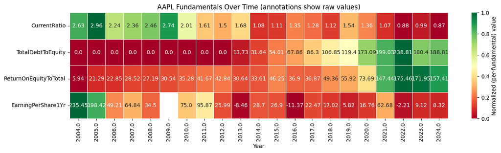

```python
# Heatmap of AAPL fundamentals over time
from sklearn.preprocessing import MinMaxScaler

ticker = 'AAPL'
fund_cols = ['CurrentRatio', 'TotalDebtToEquity', 'ReturnOnEquityToTotal', 'EarningPerShare1Yr']

aapl = lseg[lseg['Ticker'] == ticker].copy()
aapl = aapl.sort_values('year_').set_index('year_')[fund_cols]

# Normalize each row (fundamental) to 0-1 so colors are comparable across very different scales
scaler = MinMaxScaler()
aapl_scaled = pd.DataFrame(
    scaler.fit_transform(aapl),
    index=aapl.index,
    columns=aapl.columns
).T
# Transpose so fundamentals are rows, years are columns

fig, ax = plt.subplots(figsize=(14, 4))
sns.heatmap(
    aapl_scaled,
    cmap='RdYlGn',
    annot=aapl.T.round(2),  # annotate with the raw (unscaled) values
    fmt='',
    cbar_kws={'label': 'Normalized (per-fundamental) value'},
    linewidths=0.5,
    linecolor='white',
    ax=ax
)
ax.set_title(f'{ticker} Fundamentals Over Time (annotations show raw values)')
ax.set_xlabel('Year')
ax.set_ylabel('')
plt.tight_layout()
plt.show()
```

The heatmap surfaces a few patterns. ROE has stayed strong throughout, which is what you'd expect from one of the most profitable companies in the sample. The big change is in leverage with Apple's debt-to-equity sharp climb in the mid-2010s as they shifted to funding buybacks with borrowing. EPS growth is the noisiest row, with a few standout years and a few flat or negative ones. Current ratio drifted lower as Apple let working capital float down toward industry norms.

This isn't information the model uses directly, since it sees the cross-section across all 40 firms rather than single-firm trajectories. But either way it's a useful tool to check that our data is capturing the kind of business evolution we'd recognize.

### Dataset 3: Yahoo Finance

#### Pre-processing

Yahoo Finance is the source of our target variable. We pulled monthly pricing data (Open, High, Low, Close, Adjusted Close, Volume) for all 40 tickers in a single CSV. The volume column came in formatted with comma separators, which pandas reads as a string, so we strip the commas and force it to numeric.

```python
yahoo = pd.read_csv(f'{YAHOO_DIR}/Yahoo - Tickers.csv')
yahoo['Volume'] = pd.to_numeric(yahoo['Volume'].astype(str).str.replace(',', ''), errors='coerce')
yahoo.head()
```

|  | Ticker | Date | Open | High | Low | Close | Adj Close | Volume |
| --- | --- | --- | --- | --- | --- | --- | --- | --- |
| 0 | AAPL | Dec 1, 2025 | 278.01 | 288.62 | 266.95 | 271.86 | 271.61 | 924528800 |
| 1 | AAPL | Nov 1, 2025 | 270.42 | 280.38 | 265.32 | 278.85 | 278.32 | 877578200 |
| 2 | AAPL | Oct 1, 2025 | 255.04 | 277.32 | 244.00 | 270.37 | 269.86 | 1097142200 |
| 3 | AAPL | Jan 1, 2025 | 248.93 | 249.10 | 219.38 | 236.00 | 234.72 | 1200176400 |
| 4 | AAPL | Mar 1, 2025 | 241.79 | 244.03 | 208.42 | 222.13 | 221.17 | 1115239500 |

First, lets do some preprocessing by ensuring our columns are saved as the proper data type.

```python
# Convert the 'Date' column to datetime objects
yahoo['Date'] = pd.to_datetime(yahoo['Date'])
yahoo.info()
```

```
<class 'pandas.core.frame.DataFrame'>
RangeIndex: 10541 entries, 0 to 10540
Data columns (total 8 columns):
 #   Column     Non-Null Count  Dtype
---  ------     --------------  -----
 0   Ticker     10541 non-null  object
 1   Date       10541 non-null  datetime64[ns]
 2   Open       10541 non-null  float64
 3   High       10541 non-null  float64
 4   Low        10541 non-null  float64
 5   Close      10541 non-null  float64
 6   Adj Close  10541 non-null  float64
 7   Volume     10541 non-null  int64
dtypes: datetime64[ns](1), float64(5), int64(1), object(1)
memory usage: 658.9+ KB
```

Yahoo includes several types of stock performance variables:

> **Open**: stock price at the beginning of the month.

> **Close**: stock price at the end of the month.

> **High and Low**: the price range that month.

> **Adjusted Close**: closing price after adjustments for splits and dividends. Used for accurate historical performance analysis.

> **Volume**: total shares traded that month.

We use Adjusted Close to construct the forward-return target.

### Aligning Frequencies: Expanding Annual Fundamentals to Monthly

```python
# Convert 'year_' to datetime objects representing the start of the year
lseg['Date'] = pd.to_datetime(lseg['year_'].astype(int), format='%Y')

# Create a list to store expanded rows
expanded_rows = []

for index, row in lseg.iterrows():
    base_date = row['Date']
    for month_offset in range(12):
        new_date = base_date + pd.DateOffset(months=month_offset)
        new_row = row.copy()
        new_row['Date'] = new_date
        expanded_rows.append(new_row)

lseg_expanded = pd.DataFrame(expanded_rows)
lseg_expanded = lseg_expanded.drop(columns=['year_'])
lseg_expanded.insert(1, 'Date', lseg_expanded.pop('Date'))

print(f"Original LSEG rows: {len(lseg)}, Expanded to monthly: {len(lseg_expanded)}")
display(lseg_expanded.head())
```

```
Original LSEG rows: 836, Expanded to monthly: 10032
```

|  | Ticker | Date | CurrentRatio | TotalDebtToEquity | ReturnOnEquityToTotal | EarningPerShare1Yr |
| --- | --- | --- | --- | --- | --- | --- |
| 0 | COP | 2004-01-01 | 0.96375 | 35.11458 | 21.08991 | 72.68657 |
| 0 | COP | 2004-02-01 | 0.96375 | 35.11458 | 21.08991 | 72.68657 |
| 0 | COP | 2004-03-01 | 0.96375 | 35.11458 | 21.08991 | 72.68657 |
| 0 | COP | 2004-04-01 | 0.96375 | 35.11458 | 21.08991 | 72.68657 |
| 0 | COP | 2004-05-01 | 0.96375 | 35.11458 | 21.08991 | 72.68657 |

### Three-Way Merge

LSEG is now monthly and shares a Date column with FRED and Yahoo, so we can merge all three on Date and Ticker. We use inner joins to drop any row missing in one of the sources since there's no point training on incomplete observations.

```python
lseg_fred = pd.merge(lseg_expanded, fred, on='Date')
lseg_fred_yahoo = pd.merge(lseg_fred, yahoo, on=['Date', 'Ticker'])
lseg_fred_yahoo.head()
```

|  | Ticker | Date | CurrentRatio | TotalDebtToEquity | ReturnOnEquityToTotal | EarningPerShare1Yr | Fed_Funds_Rate | CPI | Yield_Spread | Unemployment | Open | High | Low | Close | Adj Close | Volume |
| --- | --- | --- | --- | --- | --- | --- | --- | --- | --- | --- | --- | --- | --- | --- | --- | --- |
| 0 | COP | 2005-01-01 | 0.91821 | 23.73556 | 28.34664 | 66.465 | 2.28 | 191.6 | 1.00 | 5.3 | 33.05 | 35.59 | 31.56 | 35.37 | 17.60 | 157718470 |
| 1 | COP | 2005-02-01 | 0.91821 | 23.73556 | 28.34664 | 66.465 | 2.50 | 192.4 | 0.79 | 5.4 | 35.60 | 43.44 | 35.58 | 42.27 | 21.04 | 194357841 |
| 2 | COP | 2005-03-01 | 0.91821 | 23.73556 | 28.34664 | 66.465 | 2.63 | 193.1 | 0.77 | 5.2 | 42.27 | 43.04 | 38.96 | 41.10 | 20.56 | 262722353 |
| 3 | COP | 2005-04-01 | 0.91821 | 23.73556 | 28.34664 | 66.465 | 2.79 | 193.7 | 0.69 | 5.2 | 41.34 | 43.07 | 37.36 | 39.96 | 19.99 | 233240112 |
| 4 | COP | 2005-05-01 | 0.91821 | 23.73556 | 28.34664 | 66.465 | 3.00 | 193.6 | 0.50 | 5.1 | 39.96 | 41.35 | 36.25 | 41.10 | 20.56 | 203494201 |

### Sector Classification

Recall that our stocks were pulled from 8 economic pools. Let's create a one hot encoded variable for this category, in case it has any effect on our models performance.

```python
ticker_to_sector = {
    'COP': 'Energy', 'CVX': 'Energy', 'EOG': 'Energy', 'SLB': 'Energy', 'XOM': 'Energy',
    'APD': 'Materials', 'FCX': 'Materials', 'NEM': 'Materials', 'NUE': 'Materials', 'SHW': 'Materials',
    'AAPL': 'Information Technology', 'AMZN': 'Information Technology', 'GOOGL': 'Information Technology',
    'MSFT': 'Information Technology', 'NVDA': 'Information Technology',
    'ABT': 'Health Care', 'JNJ': 'Health Care', 'MRK': 'Health Care', 'PFE': 'Health Care', 'UNH': 'Health Care',
    'HD': 'Consumer Discretionary', 'LOW': 'Consumer Discretionary', 'MCD': 'Consumer Discretionary',
    'NKE': 'Consumer Discretionary', 'TGT': 'Consumer Discretionary',
    'BAC': 'Financials', 'GS': 'Financials', 'JPM': 'Financials', 'MS': 'Financials', 'WFC': 'Financials',
    'CL': 'Consumer Staples', 'GIS': 'Consumer Staples', 'KO': 'Consumer Staples',
    'PEP': 'Consumer Staples', 'PG': 'Consumer Staples',
    'AEP': 'Utilities', 'D': 'Utilities', 'DUK': 'Utilities', 'ED': 'Utilities', 'SO': 'Utilities'
}

# Resulting column will be categorical strings
lseg_fred_yahoo['Sector'] = lseg_fred_yahoo['Ticker'].map(ticker_to_sector)

# Perform one-hot encoding, this will create new columns for each sector and drop the original Sector column.
merged = pd.get_dummies(lseg_fred_yahoo, columns=['Sector'])
# We also want to keep sector
merged['Sector'] = lseg_fred_yahoo['Ticker'].map(ticker_to_sector)

# Display the head of the DataFrame to verify the new column and one-hot encoded columns
display(merged.head())
```

|  | Ticker | Date | CurrentRatio | TotalDebtToEquity | ReturnOnEquityToTotal | EarningPerShare1Yr | Fed_Funds_Rate | CPI | Yield_Spread | Unemployment | ... | Volume | Sector_Consumer Discretionary | Sector_Consumer Staples | Sector_Energy | Sector_Financials | Sector_Health Care | Sector_Information Technology | Sector_Materials | Sector_Utilities | Sector |
| --- | --- | --- | --- | --- | --- | --- | --- | --- | --- | --- | --- | --- | --- | --- | --- | --- | --- | --- | --- | --- | --- |
| 0 | COP | 2005-01-01 | 0.91821 | 23.73556 | 28.34664 | 66.465 | 2.28 | 191.6 | 1.00 | 5.3 | ... | 157718470 | False | False | True | False | False | False | False | False | Energy |
| 1 | COP | 2005-02-01 | 0.91821 | 23.73556 | 28.34664 | 66.465 | 2.50 | 192.4 | 0.79 | 5.4 | ... | 194357841 | False | False | True | False | False | False | False | False | Energy |
| 2 | COP | 2005-03-01 | 0.91821 | 23.73556 | 28.34664 | 66.465 | 2.63 | 193.1 | 0.77 | 5.2 | ... | 262722353 | False | False | True | False | False | False | False | False | Energy |
| 3 | COP | 2005-04-01 | 0.91821 | 23.73556 | 28.34664 | 66.465 | 2.79 | 193.7 | 0.69 | 5.2 | ... | 233240112 | False | False | True | False | False | False | False | False | Energy |
| 4 | COP | 2005-05-01 | 0.91821 | 23.73556 | 28.34664 | 66.465 | 3.00 | 193.6 | 0.50 | 5.1 | ... | 203494201 | False | False | True | False | False | False | False | False | Energy |

5 rows × 25 columns

### Handling Missing Values

First, let's get a clear picture of how much data is missing and where.

```python
# Missing-data audit before imputation
missing = merged.isnull().sum()
missing = missing[missing > 0].sort_values(ascending=False).to_frame('Missing')
missing['Pct'] = (missing['Missing'] / len(merged) * 100).round(2)
display(missing)
print(f"\nTotal rows: {len(merged):,}")
print(f"Columns with missing data: {len(missing)} of {len(merged.columns)}")
```

|  | Missing | Pct |
| --- | --- | --- |
| CurrentRatio | 1428 | 14.95 |
| EarningPerShare1Yr | 852 | 8.92 |
| ReturnOnEquityToTotal | 204 | 2.14 |

```
Total rows: 9,552
Columns with missing data: 3 of 25
```

CurrentRatio is missing about 15% of its values, EarningPerShare1Yr about 9%, and ReturnOnEquityToTotal about 2%. All three come from LSEG and reflect years where a company didn't report. Linear interpolation estimates the missing value based on what came before and after, which is a reasonable middle ground between dropping rows and guessing blindly.

```python
# Fill missing numerical values using linear interpolation, looking both forwards and backwards
# This method approximates missing values based on the values before and after them
merged = merged.infer_objects(copy=False)
merged = merged.select_dtypes(include='number').interpolate(method='linear', limit_direction='both').combine_first(merged)

# For any remaining NaNs (e.g., at the very beginning or end of a column if no surrounding data exists), fill with 0
# The 'Volume' column should already be numeric and mostly free of NaNs from the initial load,
# but this ensures any new NaNs (e.g. from merging) or remaining NaNs in other columns are handled.
merged = merged.fillna(0)

# Display the info again to verify that all numerical columns now have no missing values
merged.info()
```

```
<class 'pandas.core.frame.DataFrame'>
RangeIndex: 9552 entries, 0 to 9551
Data columns (total 25 columns):
 #   Column                         Non-Null Count  Dtype
---  ------                         --------------  -----
 0   Adj Close                      9552 non-null   float64
 1   CPI                            9552 non-null   float64
 2   Close                          9552 non-null   float64
 3   CurrentRatio                   9552 non-null   float64
 4   Date                           9552 non-null   datetime64[ns]
 5   EarningPerShare1Yr             9552 non-null   float64
 6   Fed_Funds_Rate                 9552 non-null   float64
 7   High                           9552 non-null   float64
 8   Low                            9552 non-null   float64
 9   Open                           9552 non-null   float64
```

[output cut: 17 more lines]

The merged dataframe has 9,552 rows and 25 columns, and every numerical column is fully populated. We're ready to start exploring.

### Building the Forward Return Target

We're predicting next-month percentage returns. For each ticker on each month, the target is the percent change in adjusted close price from this month to the next. The shift makes this a forward-looking target. Predicting today's return from today's features would leak the answer.

We use adjusted close rather than raw close so the target reflects total return, accounting for dividends and splits. The last observation for each ticker has no "next month" to reference, so those rows get dropped.

```python
# Build the target of next-month percent return per ticker
# Sort first so pct_change works correctly within each ticker
merged = merged.sort_values(['Ticker', 'Date']).reset_index(drop=True)

# Forward return is (next month's Adj Close / this month's Adj Close) - 1
# Computed per ticker so we don't accidentally compute returns across stock boundaries
merged['Forward_Return'] = merged.groupby('Ticker')['Adj Close'].pct_change().shift(-1)

# Drop rows where Forward_Return is NaN (last month for each ticker has no "next month")
merged = merged.dropna(subset=['Forward_Return']).reset_index(drop=True)

print("Shape after target build:", merged.shape)
print("\nForward_Return summary:")
print(merged['Forward_Return'].describe())
print("\nSample (one ticker):")
display(merged[merged['Ticker'] == 'AAPL'][['Date', 'Adj Close', 'Forward_Return']].head(10))
```

```
Shape after target build: (9512, 26)

Forward_Return summary:
count    9512.000000
mean        0.011923
std         0.079021
min        -0.522233
25%        -0.029634
50%         0.011483
75%         0.052187
max         0.726073
Name: Forward_Return, dtype: float64

Sample (one ticker):
```

|  | Date | Adj Close | Forward_Return |
| --- | --- | --- | --- |
| 0 | 2005-01-01 | 1.15 | 0.165217 |
| 1 | 2005-02-01 | 1.34 | -0.067164 |
| 2 | 2005-03-01 | 1.25 | -0.136000 |
| 3 | 2005-04-01 | 1.08 | 0.101852 |
| 4 | 2005-05-01 | 1.19 | -0.075630 |
| 5 | 2005-06-01 | 1.10 | 0.163636 |
| 6 | 2005-07-01 | 1.28 | 0.093750 |
| 7 | 2005-08-01 | 1.40 | 0.150000 |
| 8 | 2005-09-01 | 1.61 | 0.074534 |
| 9 | 2005-10-01 | 1.73 | 0.173410 |

The average stock in our data gained about 1.2% per month, which makes sense since stocks tend to go up over time and our sample happened to catch a long stretch of good market years. Standard deviation is just under 8%, the distribution has a fat right tail (kurtosis of 4.85), and the range stretches from -52% to +73%. It is also important to note that equity returns are noisy.

A histogram makes the shape easier to see than summary statistics alone.

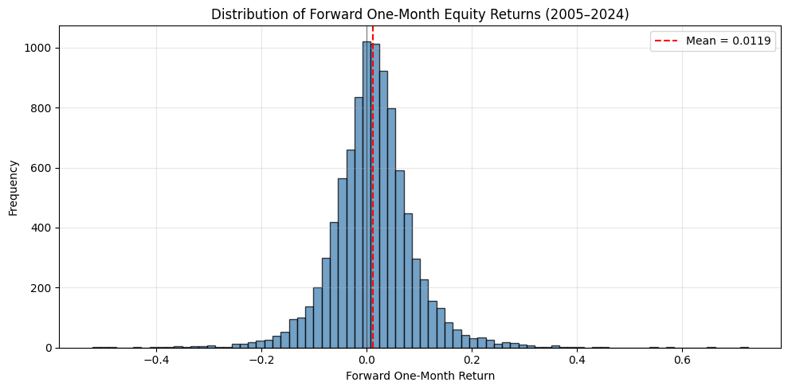

```
Mean:     0.0119
Std Dev:  0.0790
Skew:     0.2221
Kurtosis: 4.8526
```

```python
# Distribution of the target variable
fig, ax = plt.subplots(figsize=(10, 5))
ax.hist(merged['Forward_Return'], bins=80, edgecolor='black', alpha=0.75, color='steelblue')
ax.axvline(merged['Forward_Return'].mean(), color='red', linestyle='--',
           linewidth=1.5, label=f"Mean = {merged['Forward_Return'].mean():.4f}")
ax.axvline(0, color='black', linestyle='-', linewidth=0.8, alpha=0.5)
ax.set_xlabel('Forward One-Month Return')
ax.set_ylabel('Frequency')
ax.set_title('Distribution of Forward One-Month Equity Returns (2005–2024)')
ax.legend()
ax.grid(True, alpha=0.3)
plt.tight_layout()
plt.show()

print(f"Mean:     {merged['Forward_Return'].mean():.4f}")
print(f"Std Dev:  {merged['Forward_Return'].std():.4f}")
print(f"Skew:     {merged['Forward_Return'].skew():.4f}")
print(f"Kurtosis: {merged['Forward_Return'].kurtosis():.4f}")
```

Most months cluster tightly around a small positive return, which is what you'd expect, but when looking at the edges of the chart, we see long flat stretches of bars going out to -50% and +70%. There aren't many of those months, but this matters because our model gets graded on how big its misses are, not just how often it misses. A few unpredictable extreme months can drag the whole score down even if the model nails everything else.

### Defining the Feature Set and the Train-Test Split

We drop all six OHLCV columns from Yahoo (Open, High, Low, Close, Adj Close, Volume) before training. Adj Close is what we built the target from, and the other five all move with it. Leaving any of them in would basically hand the model the answer.

The remaining 16 features are four LSEG fundamentals, four FRED macro variables, and eight one-hot sector dummies. We then do a chronological split (train on 2005-2020, test on 2021-2024) since a random split would let the model peek at the future, since stock returns are correlated across months and stocks.

```python
# Adj Close, Open, High, Low, Close, Volume are leaky (they're the price itself or trivially related)
leaky_cols = ['Open', 'High', 'Low', 'Close', 'Adj Close', 'Volume']
id_cols = ['Ticker', 'Date', 'Sector']
target_col = 'Forward_Return'

feature_cols = [c for c in merged.columns
                if c not in leaky_cols + id_cols + [target_col]]

print("Features used in model:")
for f in feature_cols:
    print(f"  - {f}")
print(f"\nTotal: {len(feature_cols)} features")

# Chronological split, train on 2005-2020, test on 2021-2024
# We use a manual chronological split rather than train_test_split because random splits would let the model see future data
train_mask = merged['Date'] < '2021-01-01'
test_mask = merged['Date'] >= '2021-01-01'

X_train = merged.loc[train_mask, feature_cols]
X_test = merged.loc[test_mask, feature_cols]
y_train = merged.loc[train_mask, target_col]
y_test = merged.loc[test_mask, target_col]

print(f"\nTrain set: {len(X_train)} rows, {merged.loc[train_mask, 'Date'].min().date()} to {merged.loc[train_mask, 'Date'].max().date()}")
print(f"Test set:  {len(X_test)} rows, {merged.loc[test_mask, 'Date'].min().date()} to {merged.loc[test_mask, 'Date'].max().date()}")
```

```
Features used in model:
  - CPI
  - CurrentRatio
  - EarningPerShare1Yr
  - Fed_Funds_Rate
  - ReturnOnEquityToTotal
  - Sector_Consumer Discretionary
  - Sector_Consumer Staples
  - Sector_Energy
  - Sector_Financials
  - Sector_Health Care
  - Sector_Information Technology
  - Sector_Materials
  - Sector_Utilities
  - TotalDebtToEquity
  - Unemployment
  - Yield_Spread

Total: 16 features

Train set: 7680 rows, 2005-01-01 to 2020-12-01
Test set:  1832 rows, 2021-01-01 to 2024-11-01
```

# Exploratory Data Analysis

### Are the Features Collinear?

Tree-based models handle correlated features better than linear models, but it's still useful to know what we're working with. Collinearity means that two features carry overlapping information, which can make importance scores unclear even if it doesn't break the model. We split the heatmap into two panels (fundamentals and macro) because the cross-block correlations aren't very interesting.

[figure not shown]

```python
# LSEG fundamentals and FRED macro variables side-by-side
lseg_features = ['CurrentRatio', 'TotalDebtToEquity', 'ReturnOnEquityToTotal', 'EarningPerShare1Yr']
macro_features = ['Fed_Funds_Rate', 'CPI', 'Yield_Spread', 'Unemployment']

fig, axes = plt.subplots(1, 2, figsize=(13, 6))

sns.heatmap(merged[lseg_features].corr(), annot=True, cmap='coolwarm', center=0,
            fmt='.2f', cbar=False, square=True, ax=axes[0])
axes[0].set_title('LSEG Fundamentals')

sns.heatmap(merged[macro_features].corr(), annot=True, cmap='coolwarm', center=0,
            fmt='.2f', cbar_kws={'shrink': 0.8}, square=True, ax=axes[1])
axes[1].set_title('FRED Macroeconomic Variables')

plt.tight_layout()
plt.show()
```

### Returns by Sector

Before throwing everything at the model, it's worth seeing how much variation there is across sectors. If average forward returns are roughly the same, the sector dummies won't help the model much and if they're meaningfully different, the model has something to work with.

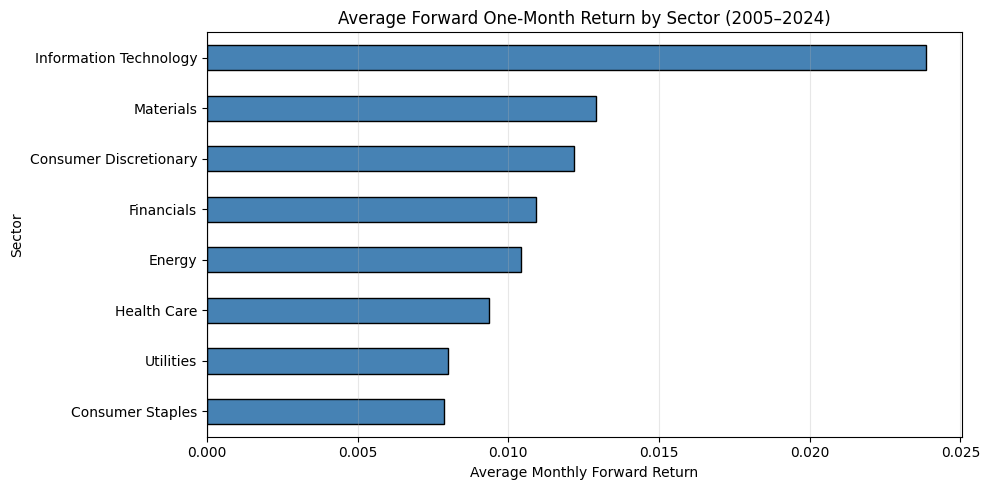

| Sector | mean | std |
| --- | --- | --- |
| Consumer Staples | 0.0079 | 0.0443 |
| Utilities | 0.0080 | 0.0485 |
| Health Care | 0.0094 | 0.0582 |
| Energy | 0.0104 | 0.0901 |
| Financials | 0.0109 | 0.0946 |
| Consumer Discretionary | 0.0122 | 0.0688 |
| Materials | 0.0129 | 0.1032 |
| Information Technology | 0.0238 | 0.0981 |

```python
# Average forward return by sector
sector_returns = merged.groupby('Sector')['Forward_Return'].agg(['mean', 'std']).sort_values('mean')

fig, ax = plt.subplots(figsize=(10, 5))
sector_returns['mean'].plot(kind='barh', ax=ax, color='steelblue', edgecolor='black')
ax.axvline(0, color='black', linewidth=0.8)
ax.set_xlabel('Average Monthly Forward Return')
ax.set_ylabel('Sector')
ax.set_title('Average Forward One-Month Return by Sector (2005–2024)')
ax.grid(True, axis='x', alpha=0.3)
plt.tight_layout()
plt.show()

display(sector_returns.round(4))
```

Information Technology is the clear standout, averaging about 2.4% per month versus 0.8% for Consumer Staples and Utilities at the bottom. That's a real spread, but also pretty obvious. The more important point is that the standard deviations are large relative to the means in every sector, which means even if sector matters on average, it explains a small fraction of the month-to-month variation we're trying to predict.

# Model Building and Hypothesis Testing

Given a stock-month's fundamentals, macro environment, and sector, can we predict next month's return better than a baseline that uses no features at all?

> Dependent variable: forward one-month percent return on adjusted close.

> Independent variables: four LSEG fundamentals (Current Ratio, Debt-to-Equity, ROE, 1-Year EPS Growth), four FRED macro indicators (Fed Funds Rate, CPI, Yield Spread, Unemployment), and eight one-hot GICS sector dummies.

Three steps. Build baselines so we know what "better" means, train a Random Forest and see if it beats them, and dig into where the model works.

Random Forest was the right tool here. Fundamentals and returns don't move together in a clean linear way, and macro variables interact with each other in ways a linear regression would miss entirely. Random Forests pick up on that kind of stuff without us having to scale features or worry about outliers throwing things off. The catch is they overfit fast on noisy data, so we have to keep them on a short leash.

### Baselines

We need a meaningful benchmark before evaluating the Random Forest. Positive R² is too easy of a bar, and so is always predicting zero. A more useful comparison is whatever a basic forecater would do without a model. For monthly stock returns, that'd be somewhere between predicting zero, predicting each ticker's historical mean, predicting each sector's historical mean, and fitting a linear regression on the same features that we'll give the Random Forest.

We test all four, but the ticker-mean and sector-mean baselines matter most. If our Random Forest can't beat the "predict each stock's average return," then it isn't doing anything useful to us.

```python
from sklearn.metrics import r2_score, mean_absolute_error, mean_squared_error

def evaluate(name, y_true, y_pred):
    r2 = r2_score(y_true, y_pred)
    mae = mean_absolute_error(y_true, y_pred)
    rmse = np.sqrt(mean_squared_error(y_true, y_pred))
    print(f"{name:25s} | R² = {r2:7.4f} | MAE = {mae:.4f} | RMSE = {rmse:.4f}")
    return {'name': name, 'r2': r2, 'mae': mae, 'rmse': rmse}

results = []

# Always predict zero return
zero_pred = np.zeros(len(y_test))
results.append(evaluate("Zero baseline", y_test, zero_pred))

# Predict each ticker's average training return
ticker_means = merged.loc[train_mask].groupby('Ticker')['Forward_Return'].mean()
ticker_mean_pred = merged.loc[test_mask, 'Ticker'].map(ticker_means).values
results.append(evaluate("Ticker-mean baseline", y_test, ticker_mean_pred))

# Predict each sector's average training return
sector_means = merged.loc[train_mask].groupby('Sector')['Forward_Return'].mean()
sector_mean_pred = merged.loc[test_mask, 'Sector'].map(sector_means).values
results.append(evaluate("Sector-mean baseline", y_test, sector_mean_pred))

# Linear regression on the same features
from sklearn.linear_model import LinearRegression
lr = LinearRegression()
lr.fit(X_train, y_train)
lr_pred = lr.predict(X_test)
results.append(evaluate("Linear Regression", y_test, lr_pred))

print("Baseline summary table:")
display(pd.DataFrame(results).set_index('name'))
```

```
Zero baseline             | R² = -0.0243 | MAE = 0.0625 | RMSE = 0.0834
Ticker-mean baseline      | R² = -0.0014 | MAE = 0.0622 | RMSE = 0.0824
Sector-mean baseline      | R² = -0.0017 | MAE = 0.0623 | RMSE = 0.0824
Linear Regression         | R² = -0.0493 | MAE = 0.0641 | RMSE = 0.0844
Baseline summary table:
```

| name | r2 | mae | rmse |
| --- | --- | --- | --- |
| Zero baseline | -0.024341 | 0.062534 | 0.083354 |
| Ticker-mean baseline | -0.001426 | 0.062243 | 0.082416 |
| Sector-mean baseline | -0.001688 | 0.062264 | 0.082427 |
| Linear Regression | -0.049251 | 0.064056 | 0.084361 |

### Random Forest

The hyperparameters here matter a lot. The pronlem we face is overfitting since with hundreds of trees of unlimited depth and only 40 stocks of data, the model memorizes training noise and generalizes poorly.

The fix for us is regularization. We use shallow trees (max_depth=4), a large minimum leaf size (min_samples_leaf=100), and feature subsampling at each split. Each of these forces the model to find patterns that hold across many observations rather than overfitting to any single ticker or month.

```python
from sklearn.ensemble import RandomForestRegressor

# Use modest depth and min_samples_leaf to prevent overfitting
# n_jobs=-1 uses all CPU cores
rf = RandomForestRegressor(
    n_estimators=500,
    max_depth=4,
    min_samples_leaf=100,
    max_features='sqrt',
    random_state=42,
    n_jobs=-1
)

print("Training regularized Random Forest...")
rf.fit(X_train, y_train)
rf_pred = rf.predict(X_test)
results.append(evaluate("RF (regularized)", y_test, rf_pred))

print("Full results comparison:")
display(pd.DataFrame(results).set_index('name'))

# Feature importance for the regularized model
print("\nFeature importances (regularized RF):")
importances2 = pd.Series(rf.feature_importances_, index=feature_cols).sort_values(ascending=False)
display(importances2)
```

```
Training regularized Random Forest...
RF (regularized)          | R² =  0.0062 | MAE = 0.0619 | RMSE = 0.0821
Full results comparison:
```

| name | r2 | mae | rmse |
| --- | --- | --- | --- |
| Zero baseline | -0.024341 | 0.062534 | 0.083354 |
| Ticker-mean baseline | -0.001426 | 0.062243 | 0.082416 |
| Sector-mean baseline | -0.001688 | 0.062264 | 0.082427 |
| Linear Regression | -0.049251 | 0.064056 | 0.084361 |
| RF (regularized) | 0.006243 | 0.061910 | 0.082100 |

```
Feature importances (regularized RF):
```

|  | 0 |
| --- | --- |
| CPI | 0.219235 |
| Unemployment | 0.176093 |
| Yield_Spread | 0.158469 |
| Fed_Funds_Rate | 0.152873 |
| EarningPerShare1Yr | 0.123619 |
| ReturnOnEquityToTotal | 0.066710 |
| CurrentRatio | 0.042297 |
| Sector_Information Technology | 0.031968 |
| TotalDebtToEquity | 0.023444 |
| Sector_Financials | 0.001554 |
| Sector_Energy | 0.001553 |
| Sector_Materials | 0.000879 |
| Sector_Consumer Staples | 0.000568 |
| Sector_Consumer Discretionary | 0.000417 |
| Sector_Utilities | 0.000166 |
| Sector_Health Care | 0.000153 |

**dtype:** float64

The regularized Random Forest gets a positive test R² of 0.0062. Small, but the only model in our comparison that actually clears zero. Most academic papers on monthly stock-return prediction report R² values in the 0.5 to 2% range, so landing positive on out of sample data counts as a real, even if modest, result.

The feature importances are where it gets interesting. The top four are all macro (CPI, Unemployment, Yield Spread, and Fed Funds Rate), features together accounting for about 71% of total importance. EPS growth and ROE come next. The sector dummies barely register, which we did not expect this. Common knowledge in finance says tech outperforms in zero-rate environments, so we figured the sector dummies would do most of the work. The model disagreed and went straight to the macro variables instead.

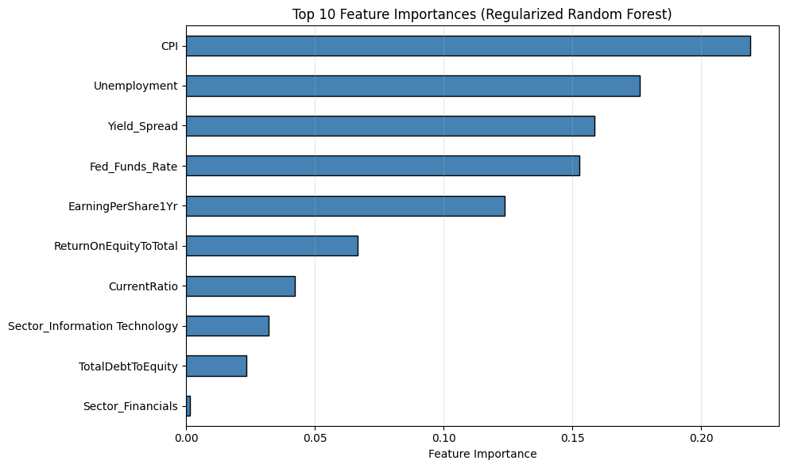

```python
# Feature importances visualized
importances = pd.Series(rf.feature_importances_, index=feature_cols).sort_values(ascending=False)

fig, ax = plt.subplots(figsize=(10, 6))
importances.head(10).sort_values().plot(kind='barh', ax=ax, color='steelblue', edgecolor='black')
ax.set_xlabel('Feature Importance')
ax.set_title('Top 10 Feature Importances (Regularized Random Forest)')
ax.grid(True, axis='x', alpha=0.3)
plt.tight_layout()
plt.show()
```

The bar chart confirms what the table showed. CPI alone accounts for over 20% of feature importance, and the four macro variables together outsize everything else. EPS growth is the only firm-level feature with meaningful weight, and we now know the dominance of macro features is what motivates the regime analysis next. If the model is mostly using macro variables, performance should depend heavily on which macro state we're currently in.

### Where Does the Model Actually Work?

A test-set R² of 0.0062 is technically positive, but small enough that a reader could write it off as noise. The more interesting question for us is whether that small overall number hides any variation across different market environments.

We split the test period (2021-2024) into macro regimes using the two dimensions our feature importances flagged as critical, rate level and inflation level.

> High-rate / high-inflation looks like classic stagflation.

> High-rate / low-inflation is tight-money disinflation.

> Low-rate / high-inflation captures the COVID stimulus aftermath.

> Low-rate / low-inflation is the boring baseline that characterized most of the 2010s.

This isn't a perfect, but it captures the main ideology. We're using rate level rather than rate change, and dividing at the median rather than a neutral level. Model performance shouldn't be the same across regimes, and breaking it down should tell us when our features can predict returns.

```python
# Build a test-set dataframe with predictions and regime labels
test_df = merged.loc[test_mask].copy()
test_df['rf_pred'] = rf_pred

# Define macro regimes using Fed Funds Rate
# High rate = above the test-period median, Low rate = below
ffr_median = test_df['Fed_Funds_Rate'].median()
test_df['Rate_Regime'] = np.where(test_df['Fed_Funds_Rate'] > ffr_median,
                                    'High Rate', 'Low Rate')

# Define inflation regimes using CPI year-over-year change
# We need to compute YoY CPI change first
cpi_by_date = merged.drop_duplicates('Date')[['Date', 'CPI']].sort_values('Date')
cpi_by_date['CPI_YoY'] = cpi_by_date['CPI'].pct_change(periods=12)
test_df = test_df.merge(cpi_by_date[['Date', 'CPI_YoY']], on='Date', how='left')

cpi_median = test_df['CPI_YoY'].median()
test_df['Inflation_Regime'] = np.where(test_df['CPI_YoY'] > cpi_median,
                                        'High Inflation', 'Low Inflation')

# Evaluate model performance within each regime
print("Performance by Rate Regime")
for regime in ['High Rate', 'Low Rate']:
    sub = test_df[test_df['Rate_Regime'] == regime]
    r2 = r2_score(sub['Forward_Return'], sub['rf_pred'])
    mae = mean_absolute_error(sub['Forward_Return'], sub['rf_pred'])
    print(f"{regime:15s} | n = {len(sub):4d} | R² = {r2:7.4f} | MAE = {mae:.4f}")

print("\nPerformance by Inflation Regime")
for regime in ['High Inflation', 'Low Inflation']:
    sub = test_df[test_df['Inflation_Regime'] == regime]
    r2 = r2_score(sub['Forward_Return'], sub['rf_pred'])
    mae = mean_absolute_error(sub['Forward_Return'], sub['rf_pred'])
    print(f"{regime:15s} | n = {len(sub):4d} | R² = {r2:7.4f} | MAE = {mae:.4f}")

# Cross-tab: rate × inflation
print("\nPerformance by Rate × Inflation Regime (4 quadrants)")
for rate_r in ['High Rate', 'Low Rate']:
    for infl_r in ['High Inflation', 'Low Inflation']:
        sub = test_df[(test_df['Rate_Regime'] == rate_r) &
                      (test_df['Inflation_Regime'] == infl_r)]
        if len(sub) > 0:
            r2 = r2_score(sub['Forward_Return'], sub['rf_pred'])
            mae = mean_absolute_error(sub['Forward_Return'], sub['rf_pred'])
            print(f"{rate_r:10s} + {infl_r:14s} | n = {len(sub):4d} | R² = {r2:7.4f} | MAE = {mae:.4f}")
```

```
Performance by Rate Regime
High Rate       | n =  912 | R² = -0.0075 | MAE = 0.0549
Low Rate        | n =  920 | R² =  0.0115 | MAE = 0.0688

Performance by Inflation Regime
High Inflation  | n =  880 | R² =  0.0178 | MAE = 0.0703
Low Inflation   | n =  952 | R² = -0.0283 | MAE = 0.0541

Performance by Rate × Inflation Regime (4 quadrants)
High Rate  + High Inflation | n =  160 | R² =  0.0287 | MAE = 0.0693
High Rate  + Low Inflation  | n =  752 | R² = -0.0384 | MAE = 0.0519
Low Rate   + High Inflation | n =  720 | R² =  0.0104 | MAE = 0.0706
Low Rate   + Low Inflation  | n =  200 | R² = -0.1126 | MAE = 0.0625
```

Our read on this is that when inflation is high and rates are rising, the cost of capital actually matters, so fundamentals like leverage and earnings growth start carrying real weight. When inflation is low and rates are low, anyone can borrow cheaply, fundamentals matter less, and returns are driven more by sentiment and flows that our features don't pick up. The model has skill when the environment makes its features relevant.

Sample sizes do complicate this a bit. The high-rate / low-inflation cell has 752 observations with a negative R², while high-rate / high-inflation has only 160 with the highest R². We don't want to lean too hard on 160 observations, but the direction (better in tighter, more inflationary regimes) lines up with economic logic.

The numbers are easier to absorb visually.

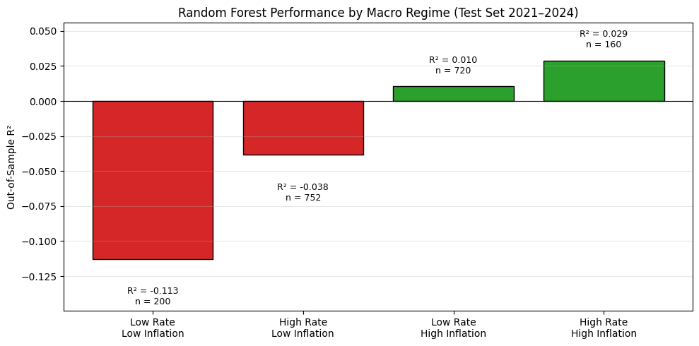

```python
# R² across the four macro regime quadrants
quadrant_results = []
for rate_r in ['High Rate', 'Low Rate']:
    for infl_r in ['High Inflation', 'Low Inflation']:
        sub = test_df[(test_df['Rate_Regime'] == rate_r) &
                      (test_df['Inflation_Regime'] == infl_r)]
        if len(sub) > 0:
            quadrant_results.append({
                'Regime': f"{rate_r}\n{infl_r}",
                'R2': r2_score(sub['Forward_Return'], sub['rf_pred']),
                'n': len(sub)
            })
quad_df = pd.DataFrame(quadrant_results).sort_values('R2')

fig, ax = plt.subplots(figsize=(10, 5))
colors = ['#d62728' if r < 0 else '#2ca02c' for r in quad_df['R2']]
bars = ax.bar(quad_df['Regime'], quad_df['R2'], color=colors, edgecolor='black')

for bar, r2_val, n in zip(bars, quad_df['R2'], quad_df['n']):
    height = bar.get_height()
    label_y = height + 0.008 if height >= 0 else height - 0.02
    ax.text(bar.get_x() + bar.get_width()/2, label_y,
            f"R² = {r2_val:.3f}\nn = {n}",
            ha='center', va='bottom' if height >= 0 else 'top', fontsize=9)

ax.axhline(0, color='black', linewidth=0.8)
ax.set_ylabel('Out-of-Sample R²')
ax.set_title('Random Forest Performance by Macro Regime (Test Set 2021–2024)')
ax.grid(True, axis='y', alpha=0.3)
ax.set_ylim(ax.get_ylim()[0] - 0.03, ax.get_ylim()[1] + 0.02)
plt.tight_layout()
plt.show()
```

The chart makes the asymmetry obvious. Two green bars, two red bars, and the worst one isn't small. The model has conditional skill, and the condition is the macro environment.

## Conclusions

We set out to test whether company fundamentals and macro conditions could predict next-month equity returns. The short answer is barely, and only in some regimes.

The full-sample numbers are pretty easy to dismiss. A test-set R² of 0.0062 is positive but small, and most readers would call it noise, but splitting by macro regime tells us a different story. The model's R² in high-rate / high-inflation environments is 0.029, while in low-rate / low-inflation environments it's -0.112.

First, aggregate metrics can hide regime dependent skill. A model that looks marginal on average can be useful in some environments while actively being harmful in others. Whenever the underlying environment changes over time, a single performance number averaged across the whole sample is going to be misleading.

Second, macro variables dominated our feature importances, which we didn't expect. We figured sector and fundamental ratios would do most of the work. Instead, CPI, Unemployment, Yield Spread, and Fed Funds together accounted for 71% of total importance, and the sector dummies were nearly useless.

### Limitations

Our 40-stock sample is survivor-biased toward names that traded continuously across the full window. Expanding annual fundamentals out to monthly creates jumps in the data where the actual numbers would have been revised gradually. The four-quadrant regime split is rough too. We chopped at the median because it was easy, not because there's anything special about that cutoff, and the best-performing cell only has 160 observations to lean on.

### Where This Could Go Next

A few natural extensions would be to expand to a few hundred stocks, replace annual fundamentals with quarterly data, add cross-sectional features like relative valuation and momentum, and to test regime-dependence with a finer grid than 2x2.

### Further Reading

> [Bridgewater on the four-quadrant economic framework](https://www.bridgewater.com/research-and-insights/the-all-weather-story)

> [Corporate Finance Institute's guide to financial ratios](https://corporatefinanceinstitute.com/resources/accounting/financial-ratios/)

> [Asness, Frazzini, and Pedersen's "Quality Minus Junk"](https://papers.ssrn.com/sol3/papers.cfm?abstract_id=2312432)

> [scikit-learn Random Forest documentation](https://scikit-learn.org/stable/modules/generated/sklearn.ensemble.RandomForestRegressor.html)

> [FRED data dictionary](https://fred.stlouisfed.org/)

```python
%%shell
jupyter nbconvert --to html '/content/drive/MyDrive/Data Science Project/Nora_and_Kyle,_Data_Science_Final_Project.ipynb' --output index.html
```

```
[NbConvertApp] Converting notebook /content/drive/MyDrive/Data Science Project/Nora_and_Kyle,_Data_Science_Final_Project.ipynb to html
[NbConvertApp] WARNING | Alternative text is missing on 8 image(s).
[NbConvertApp] Writing 1107776 bytes to /content/drive/MyDrive/Data Science Project/index.html
```